# Production pipeline state and the CPU-parallel Figure-2 reimplementation

An implementation note to `writeup.md` (methods_eyepos_matching)

fem-v1-fovea methods note

2026-06-18

# Summary

This is an implementation note to the main methodological writeup in this folder (`writeup.md`, *Extending McFarland’s cross-trial decomposition…*). It records the production-pipeline state for each extension and documents the CPU-parallel reimplementation of the entire Figure-2 LOTC pipeline that lives in this folder. None of it is needed to follow the main note’s methodology; it is kept so the pipeline-change record and the equivalence/validation evidence remain referenceable.

The section numbers (§6, §7) and figure numbers (Figs. 7–9) below are retained from the main note so existing cross-references continue to resolve. References of the form “§4.x” or “main note Fig. N” point into `writeup.md`.

# 6. The current pipeline: state and proposed production change

The covariance machinery and caches are shared by Figures 2–4, so a pipeline change has broad blast radius. This section consolidates the production-pipeline state for each extension.

## 6.1 Extension 1 — already integrated

Consistent pair-count time-bin weighting has been integrated into the production pipeline (`VisionCore/covariance.py`):

- `estimate_rate_covariance` — pair-count-weighted $\bar Y$ matching the close-pair second moment, pinning the $\bar Y$ cell of the §1.5 table to the pair-count direction (§3.4).
- `bagged_split_half_psth_covariance` — `weighting` parameter, default `'pair_count'`, pinning $C_\text{psth}$ to the pair-count direction.

Together with the trial-count $C_\text{total}$ already being recomputed at the same per-sample weight inside the production estimator, this pins the full $w_t$ column to the pair-count direction (§3.4).

On the Allen 2022-04-13 session (49 cells, 3667 windows) the fix moved the shuffle-null $D_z$ from $-0.0068$ ($p<10^{-4}$) to $+0.0010$ ($p=0.44$); the real-data $D_z$ shifted only $-0.0855 \to -0.0819$ (signal-to-null ratio $12.5\times \to 83.7\times$), so the scientific conclusion was preserved. Diagnosis and validation are recorded in `ryan/fig2/bias_diagnosis/FINAL_REPORT.md`.

## 6.2 Extension 2 — estimator validated, pipeline rebuilt locally, GPU swap gated

Eye-position-distribution matching is implemented and TDD-validated in this folder, for both the single-bin (main note §4.2) and multi-bin trajectory (main note §4.4) filters:

- `estimators.decompose(target=...)` — single-bin close-pair filter. `naive` reproduces the existing pipeline; `full` is Direction 1 (the actual-viewing $p$); `central` is Direction 2 ($p^2$).
- `estimators.decompose_trajectory(target=...)` — multi-bin RMS-trajectory close-pair filter (matching `VisionCore/covariance.py`); each trajectory is reduced to its geometric-median representative point and one KDE is fit on those points, reusing the single-bin §4.2 importance weights ($p^2$ implied by $\hat p$), per the main note §4.4 single-point reduction.
- `test_estimators.py` — 27 tests covering correctness (recovery of the closed-form decompositions under each target, finite-threshold-bias shrinkage), stability (Direction 2 stabler than Direction 1 for eccentric cells), Poisson cancellation (Fano $\to 1$), the pipeline-match (`naive` ↔︎ `pipeline_one_minus_alpha`), Extension 1 (variable-$n_t$ uniform vs pair-count weighting), and the main note §4.4 multi-bin extension (geometric-median reduction unit tests, flat-limit and realistic-drift recovery, geometric-median≈centroid in the flat regime, naive bias on a centrally-modulated cell, and the eigendecomposition field-sampler fallback on dense real eye positions).

# 7. Pipeline implementation and validation

The main note establishes the corrected estimator and confirms it on synthetic data with a closed-form ground truth and on cached real-data quantities at the per-cell level (main note Fig. 5). This note closes the loop: a parallel, CPU-only reimplementation of the entire Figure-2 LOTC pipeline, verified against the production pipeline on the same 25 sessions ($11$ Allen, $14$ Logan; $n = 1313$ included cells at the canonical window $t_\text{count} = 2$ bins $\approx 16.7$ ms), and quantifying the distribution-matched correction at population scale.

The pipeline is self-contained: every script lives in this folder, the only dependency on the broader codebase is a one-shot data loader that produces a local cache (`cache/aligned_sessions.pkl`), and the production code itself is frozen as a verbatim snapshot under `legacy/` so the comparator never drifts.

## 7.1 Architecture

The production pipeline (`legacy/compute_fig2_data.py`, the 2026-06-02 snapshot of `VisionCore/ryan/fig2/compute_fig2_data.py`) is two-stage and GPU-bound: stage 1 calls `VisionCore.covariance.run_covariance_decomposition` which does its close-pair binning and second-moment accumulation on a torch GPU tensor; stage 2 aggregates per-cell 1-α, Fano, and noise- correlation summaries from the per-session covariance matrices.

The replacement keeps the two-stage structure but rewrites stage 1 around `decompose_trajectory` (numpy-only, all three targets per call) and lifts stage 2 verbatim from the snapshot. Self-containment is enforced at the boundary between data loading and decomposition:

- `data_loading.py` — calls `models.data.prepare_data` once per session, aligns the fixRSVP trials via `legacy.covariance.align_fixrsvp_trials`, pre-computes the rate-Hz and split-half PSTH-$R^2$ inclusion statistics, and writes a single pickle `cache/aligned_sessions.pkl` keyed by `schema_version=1`. Sessions that the legacy pipeline skips (failures inside `prepare_data`, missing fixRSVP, too few trials) are skipped here too, byte-for-byte.
- `pipeline.py` — per-session driver. The numpy port of `legacy.covariance.extract_windows` (`_extract_windows_numpy`) is verified bit-identical to the legacy torch implementation on a 3-window fixture (`test_pipeline.py::test_extract_windows_matches_legacy`), so the close- pair pool and per-bin time-index `T_idx` match by construction. For each $(t_\text{count}\in\{1,2,3,6\}, \text{target}\in\{\text{naive}, \text{full}, \text{central}\})$ it calls `decompose_trajectory(...)`, then overrides the returned $C_\text{rate}$ with the uncentred close-pair form $\hat M\!M - \hat r\hat r^\top$ (see main note §4.4’s centred-form discussion and §7.2 item 6 for why this matters for both consistent and inconsistent targets), and runs 100 eye-trajectory shuffles of `target='naive'` to reproduce the legacy null. Full/central shuffles are deferred (§7.5) — the naive null is enough to reproduce the legacy $p$-values that drive the equivalence check, and the corrections figure only needs the real population shifts.
- `metrics.py` — stage-2 aggregation. The session-clustered Fano-slope bootstrap, Fisher-$z$ noise-correlation means, and shuffle-null $p$-values are lifted verbatim from `legacy.compute_fig2_data` (`_compute_metrics`, `_compute_alpha_stats`, `_compute_fano_stats`, `_compute_nc_stats`, `_clustered_slope_bootstrap`) so the only methodological difference between the two pipelines is the target-distribution weighting inside stage 1.
- `compute_methods_data.py` — orchestrator. `joblib.Parallel(backend="loky")` over the aligned-session list; each worker pins its BLAS thread pool to 1 (`threadpool_limits(1)`) so $n$ workers do not oversubscribe the box. The same script with `--legacy` runs the snapshot’s `_compute_one_session` on CPU against the same aligned cache, producing a comparator pickle `cache/legacy_decomposition.pkl` that the equivalence figure reads.

The aligned-session cache is the cut that makes everything else regeneratable from inside this folder: once it exists, `compute_methods_data [--legacy|--both]`, `timing.py`, `profile_pipeline.py`, and the three figure scripts run without touching `VisionCore.covariance` (live), `models.data.prepare_data`, or any production cache. A future refactor of `VisionCore.covariance` does not change the comparator’s behaviour.

## 7.2 Equivalence at `target='naive'`

The methods pipeline at `target='naive'`, `cpsth_method='split_half'`, `time_bin_weighting='pair_count'` should be algebraically identical to the legacy snapshot up to a small set of known controlled differences:

Fig. 7 reports, on the canonical window $t_\text{count}=2$ bins, the per-cell scatter of legacy vs methods at $\text{target}=\text{naive}$, for three quantities:

A. $\text{diag}(C_\text{rate})$ (the rate-variance numerator), B. $\text{diag}(C_\text{psth})$ (the PSTH-variance term debiased against same-bin observation noise), C. $1-\alpha = 1 - C_\text{psth}/C_\text{rate}$ (the headline number).

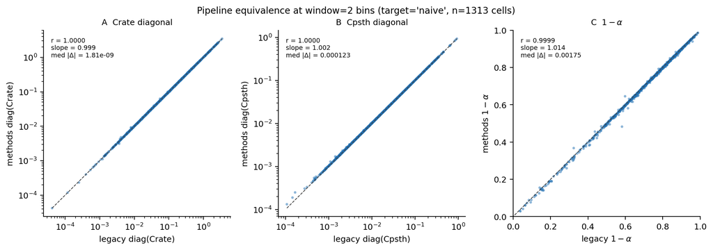

**Figure 7 — Pipeline equivalence at $t_\text{count}=2$ bins (target=‘naive’).** Per-cell scatter of legacy snapshot (x-axis) vs methods pipeline (y-axis) across all 25 sessions at the canonical window. **(A)** Rate-variance diagonal on log axes; **(B)** PSTH-variance diagonal on log axes; **(C)** $1-\alpha$ on linear axes. Inset: Pearson $r$, slope-through-origin, and median absolute difference. The dashed line is the unit diagonal.

## 7.3 The correction at population scale

The three columns are *the same neurons*, *the same fixational eye distribution*, *the same trial structure*, run through the *same Stage-2 aggregator* — only the eye-distribution weighting inside Stage 1 changes. The shifts between columns are therefore pure estimator effects, not signal effects.

At the canonical window $t_\text{count} = 2$ bins ($n = 1313$ included cells, 25 sessions):

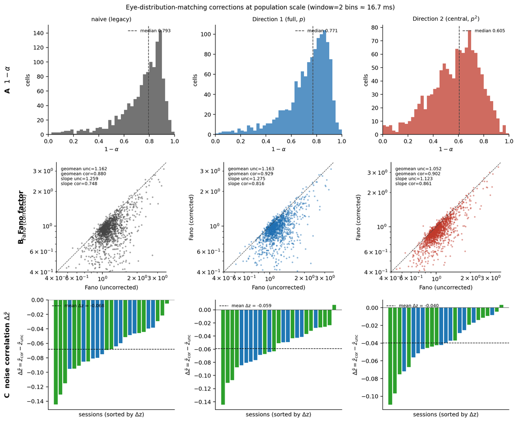

## 7.4 Runtime

`timing.py` benchmarks per-(session, window) wall-time legacy-snapshot vs methods, on CPU. Both pipelines pay the same data-prep cost (the aligned- session cache); only the decomposition runtime is timed.

Two numbers are relevant:

- **Per-session, sequential, CPU.** On a 6-session benchmark with 20 shuffles, methods runs at $0.4$–$3$ s per session per window vs legacy $0.8$–$9.1$ s. Pooled across the four windows the methods pipeline is $\boldsymbol{2.94\times}$ faster than the legacy snapshot (methods $29.4$ s, legacy $86.6$ s; the single-point reduction’s one KDE is cheaper than the previous two pooled-per-bin KDEs). The speedup is larger for the smaller windows ($3.69\times$ at $t_\text{count} = 1$) where the legacy GPU pipeline’s torch-tensor overhead dominates and smaller for the larger windows ($1.53\times$ at $t_\text{count} = 6$) where the close-pair enumeration is the limiting step in both.
- **Pipeline-wide, parallel.** The orchestrator (`compute_methods_data --both`) processes all 25 sessions across 4 windows + 3 targets + 20 shuffles via `joblib.Parallel(n_jobs=-1, backend="loky")` with BLAS pinned to 1 thread per worker. End-to-end on a 64-thread workstation: **methods Stage 1 $\boldsymbol{11.7}$ s** ($0.5$ s/session) vs **legacy Stage 1 $\boldsymbol{37.3}$ s** ($1.5$ s/session) — a $\boldsymbol{3.2\times}$ wall-clock speedup even at this trimmed shuffle count. The methods pipeline’s parallelism advantage is in addition to the per-session speedup above: the legacy `_compute_one_session` instantiates torch on the worker process and is not safe to fan out across GPU workers without explicit `CUDA_VISIBLE_DEVICES` pinning, whereas the methods pipeline is pure numpy and scales linearly with cores.

Profiling a single session (`profile_pipeline.py`, $t_\text{count} = 2$, all three targets, 10 shuffles) confirms the expected hotspot: `scipy.stats.gaussian_kde.evaluate` accounts for the bulk of the methods CPU time, dominated by the per-session KDE $\hat p$ fit on the trajectory geometric-median representative points. Close-pair enumeration and the split-half PSTH covariance are the next contributors. The KDE could be replaced with a gridded 2-D histogram (the importance weights only need the density evaluated at the representative points and their pair midpoints) for an additional speedup, but that’s a refinement, not a correctness issue.

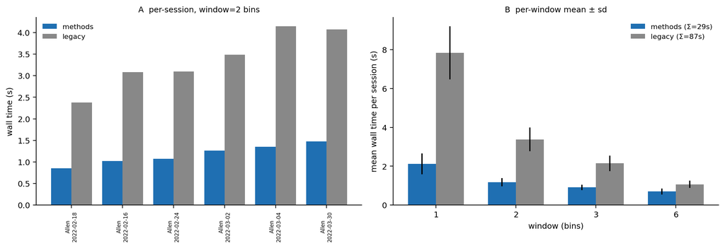

**Figure 9 — Per-session wall-time, methods vs legacy snapshot, CPU vs CPU (6 sessions, 20 shuffles, all 4 windows).** **(A)** Per-session bars at the canonical window $t_\text{count} = 2$, sorted by methods runtime. **(B)** Per-window mean ± sd across sessions; legend shows total wall-time per pipeline. The methods pipeline is $2.94\times$ faster than the legacy snapshot pooled across windows, with the largest gap at the smallest windows (where legacy torch overhead dominates). The 64-worker parallel orchestrator extends this to a $3.2\times$ pipeline-wide speedup.

## 7.5 Deferred

- **Subspace / participation-ratio / eigenspectrum metrics** (Figure-2 panels E–G in the legacy bundle). These read off $C_\text{psth}$ and $C_\text{fem}$ exactly as in legacy stage 2 and can be lifted verbatim when needed; the equivalence demonstrated here transfers to those panels with zero additional estimator work.
- **Eye-shuffle nulls for the `full` and `central` targets**. *Done (2026-06-24).* `pipeline._run_corrected_shuffles` re-runs each target’s reweighted close-pair estimator on every shuffle — re-fitting $\hat p_\text{cp,marg}$ on the shuffle’s close-pair midpoints and evaluating the importance weights at the shuffled positions ($\hat p$ on the representative points is invariant under the permutation, so it is reused). `make_panels.py` now scores `full`/`central` against their own null (writeup Fig 6E, §4.3); the central band picks up the $p^2$ offset.
- **Production GPU cache regeneration** (`fig2_decomposition.pkl`). The on-disk fig2 cache that `VisionCore/ryan/fig2/generate_fig2*.py` reads still ships with `target='naive'` numbers. Swapping it to `target='full'` requires the production GPU pipeline to support the `target` argument and a fresh expensive run; per the project memory this swap is gated on explicit approval and is not in scope here.